# Model check parameterization

2023-03-31

## Overview

A model check’s appearance depends on parameterization and sampling decisions. These should be informed by statistical theory and empirical evidence on cognitive capabilities and limitations for graphical statical inference.

In this document, we generate a few model checks to demonstrate the ways that different choices can dramatically impact the appearance of a model check visualization, and thus impact the user’s judgment of the discrepancy between the data and the model predictions.

## Student absences data

For our example, we’ll use the student absenses dataset described in the paper.

```r
df = read.csv("eval_students.csv")
```

We’ll do some simple prep for modeling this data with a log normal distribution.

```r
df = df |>
  filter(absences != 0) |>
  mutate(
    g_edu = as.factor(g_edu),
    log_absences = log(absences))
```

## Prior predictive checks

First we will specify and sample a couple prior predictive checks in order to show how the appearance of the model check depends on the choice of prior.

For our example model, we will consider a case similar to model checks created by participants in our user study. Specifically, we will specify a model that includes predictors we might expect to be associated with socioeconomic status and a student’s home life more broadly, guardian education, guardian job, and internet access. The model checks we show are meant to examine whether time the student spends studying still seems like an explanatory factor after accounting for these other variables.

### Default, uninformative priors

In this first example, we’ll use the defaults provided by `brms`.

```r
get_prior(
  bf(log_absences ~ g_edu + g_job + internet),
  family = gaussian,
  data = df)
```

```
##                   prior     class          coef group resp dpar nlpar lb ub
##                  (flat)         b
##                  (flat)         b        g_edu2
##                  (flat)         b        g_edu3
##                  (flat)         b        g_edu4
##                  (flat)         b   g_jobhealth
##                  (flat)         b    g_jobother
##                  (flat)         b g_jobservices
##                  (flat)         b  g_jobteacher
##                  (flat)         b   internetyes
##  student_t(3, 1.4, 2.5) Intercept
##    student_t(3, 0, 2.5)     sigma                                      0
##        source
##       default
##  (vectorized)
##  (vectorized)
##  (vectorized)
##  (vectorized)
##  (vectorized)
##  (vectorized)
##  (vectorized)
##  (vectorized)
##       default
##       default
```

We will use a student t distribution for beta coefficients instead of the default flat prior, but both of these choices impose minimal regularization.

```r
m_prior_default = brm(
  bf(log_absences ~ g_edu + g_job + internet),
  family = gaussian,
  prior = c(prior(student_t(3, 1.4, 2.5), class = Intercept),
            prior(student_t(3, 0, 2.5), class = b),
            prior(student_t(3, 0, 2.5), class = sigma)),
  data = df,
  sample_prior = "only")
```

```
## Trying to compile a simple C file
```

[output not shown]

Now, we’ll sample predicted draws from the model and visualize them in a model check mimicking the design we used in EVM.

```r
p_default_df = df |>
  add_predicted_draws(m_prior_default, ndraws = 20) |>
  rename(
    y = log_absences,
    y_rep = .prediction) |>
  pivot_longer(cols=c('y', 'y_rep'),
                    names_to='Model group',
                    values_to='log_absences')
```

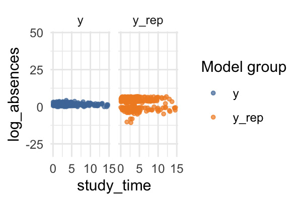

```r
p_default_mc = p_default_df |>
  ggplot(aes(x = study_time, y = log_absences, color = `Model group`)) +
  geom_point(alpha = 0.7, size = 1) +
  scale_color_tableau(palette = "Tableau 10") +
  facet_grid(. ~ `Model group`) +
  theme_minimal() +
  transition_manual(.draw)

animate(p_default_mc, nframes = 20, fps = 2.5, res = 200, units = "in", height = 2, width = 3)
```

We can see that the resulting model check is highly variables in the appearance of the predictive distribution. This results in a y-axis scale that is blown up so much that it’s difficult to see the structure in the original data. A visual analytics user might not get much from a prior predictive check without priors that are more carefully chosen.

### Weakly informative priors

In this next example, we’ll define weakly informed priors following a similar approach to what we’ve done using these tools for previous empirical work.

To start this means centering the intercept prior at the empirical mean of `log_absences`, 1.62.

```r
df$log_absences |> mean()
```

```
## [1] 1.619246
```

We will also reduce the variance parameters of our priors until we get a range of prior predictions that roughly matches the scale of the observed data. This fine tuning is a process of trial and error, but it can probably be automated with a carefully written algorithm. A few rounds of iterative model checking reveals that the default, uninformative priors we get from `brms` are about an order of magnitude too large to support a legible prior predictive check visualization. We do not mean to suggest, however, that these defaults are improper for statistical inference. Uninformative priors are intended to provide users with a reasonable starting place for fitting with an MCMC algorithm, without knowing anything about their data. Prior predictive checking, on the other hand, often requires domain knowledge and a rough match to the high-level summary statistics of the observed data as we demonstrate here.

```r
m_prior_weak = brm(
  bf(log_absences ~ g_edu + g_job + internet),
  family = gaussian,
  prior = c(prior(student_t(3, 1.62, 0.25), class = Intercept),
            prior(student_t(3, 0, 0.25), class = b),
            prior(student_t(3, 0, 0.25), class = sigma)),
  data = df,
  sample_prior = "only")
```

```
## Trying to compile a simple C file
```

[output not shown]

Now, as before, we’ll sample predicted draws from the model and visualize them in a model check.

```r
p_weak_df = df |>
  add_predicted_draws(m_prior_weak, ndraws = 20) |>
  rename(
    y = log_absences,
    y_rep = .prediction) |>
  pivot_longer(cols=c('y', 'y_rep'),
                    names_to='Model group',
                    values_to='log_absences')
```

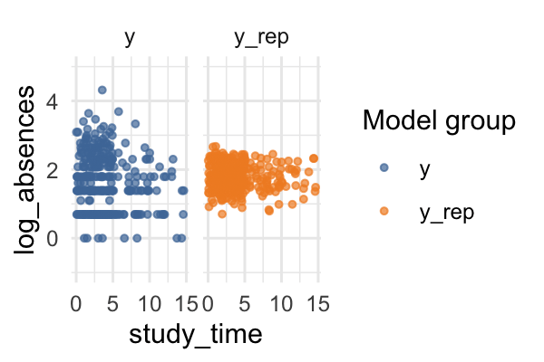

```r
p_weak_mc = p_weak_df |>
  ggplot(aes(x = study_time, y = log_absences, color = `Model group`)) +
  geom_point(alpha = 0.7, size = 1) +
  scale_color_tableau(palette = "Tableau 10") +
  facet_grid(. ~ `Model group`) +
  theme_minimal() +
  ylim(-1, 5) +
  transition_manual(.draw)

animate(p_weak_mc, nframes = 20, fps = 2.5, res = 200, units = "in", height = 2, width = 3)
```

## Posterior predictive checks

This last example where we fit a model to the data before sampling predictions from it is similar to what we do in EVM.

```r
m_fitted = brm(
  bf(log_absences ~ g_edu + g_job + internet),
  family = gaussian,
  prior = c(prior(student_t(3, 1.4, 2.5), class = Intercept),
            prior(student_t(3, 0, 2.5), class = b),
            prior(student_t(3, 0, 2.5), class = sigma)),
  data = df,
  iter = 2000, warmup = 1000, chains = 4)
```

```
## recompiling to avoid crashing R session
```

```
## Trying to compile a simple C file
```

[output not shown]

After fitting Bayesian regression models like this, it’s good practice to look at a few diagnostics.

```r
summary(m_fitted)
```

```
##  Family: gaussian
##   Links: mu = identity; sigma = identity
## Formula: log_absences ~ g_edu + g_job + internet
##    Data: df (Number of observations: 340)
##   Draws: 4 chains, each with iter = 2000; warmup = 1000; thin = 1;
##          total post-warmup draws = 4000
##
## Population-Level Effects:
##               Estimate Est.Error l-95% CI u-95% CI Rhat Bulk_ESS Tail_ESS
## Intercept         1.21      0.16     0.91     1.53 1.00     3049     2808
## g_edu2            0.25      0.14    -0.02     0.53 1.00     2410     2411
## g_edu3            0.45      0.15     0.16     0.74 1.00     2437     2850
## g_edu4            0.20      0.17    -0.14     0.55 1.00     2199     2458
## g_jobhealth      -0.23      0.21    -0.65     0.17 1.00     2502     2851
## g_jobother       -0.12      0.13    -0.39     0.14 1.00     2154     2504
## g_jobservices    -0.08      0.15    -0.38     0.20 1.00     2176     2522
## g_jobteacher     -0.26      0.20    -0.65     0.12 1.00     2312     2686
## internetyes       0.34      0.12     0.11     0.57 1.00     4133     3197
##
## Family Specific Parameters:
##       Estimate Est.Error l-95% CI u-95% CI Rhat Bulk_ESS Tail_ESS
## sigma     0.80      0.03     0.74     0.86 1.00     4418     2801
##
## Draws were sampled using sampling(NUTS). For each parameter, Bulk_ESS
## and Tail_ESS are effective sample size measures, and Rhat is the potential
## scale reduction factor on split chains (at convergence, Rhat = 1).
```

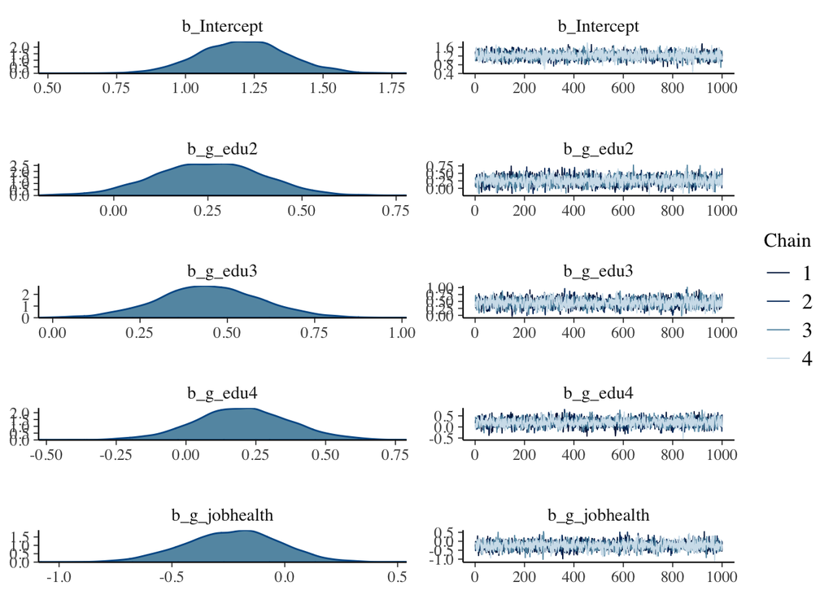

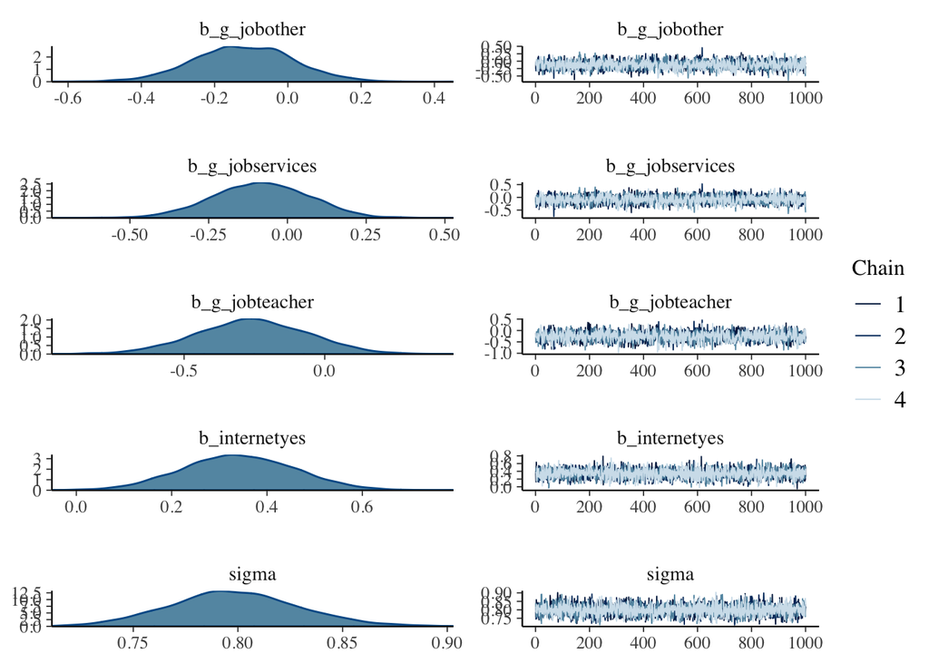

```r
plot(m_fitted)
```

Now, we’ll sample and plot the model check as above.

```r
fitted_df = df |>
  add_predicted_draws(m_fitted, ndraws = 20) |>
  rename(
    y = log_absences,
    y_rep = .prediction) |>
  pivot_longer(cols=c('y', 'y_rep'),
                    names_to='Model group',
                    values_to='log_absences')
```

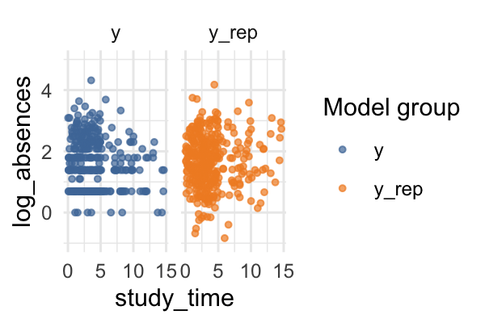

```r
fitted_mc = fitted_df |>
  ggplot(aes(x = study_time, y = log_absences, color = `Model group`)) +
  geom_point(alpha = 0.7, size = 1) +
  scale_color_tableau(palette = "Tableau 10") +
  facet_grid(. ~ `Model group`) +
  theme_minimal() +
  ylim(-1, 5) +
  transition_manual(.draw)

animate(fitted_mc, nframes = 20, fps = 2.5, res = 200, units = "in", height = 2, width = 3)
```

This model check resembles the ones that users see in EVM. Note that some of the stronger visual signals for potential misfit are dampened in this view compared to the prior predictive check with weakly informative priors above.

## Summary

Designing EVM with approximate posterior predictive checks was a good starting point aligned with practices in a typical Bayesian workflow. However, it is worth considering the possibility of enabling users of a tool like EVM to work with prior predictive checks, since carefully crafted priors can probably yield model check visualizations that carry more signal about the incompatibility of assumptions with observed data. However, designing the scaffolding, defaults, and guardrails required for interactive prior predictive checking will require further research.